# Homework 01

## Question 1 (Least squares and matrix calculations)

### Answer

#### a. Dimensions, rank, and parameter comparison

The design matrix $\mathbf X$ has dimensions $100 \times 6$: 100 observations and 6 columns, including the intercept. Its rank is 6, so it has full column rank.

I used `np.linalg.lstsq`, a numerically stable least-squares routine, to calculate $\widehat{\boldsymbol\beta}$ without explicitly inverting $\mathbf X^{\mathsf T}\mathbf X$.

| Parameter | True value | Estimated value | Difference |
| --- | --- | --- | --- |
| Intercept ($\beta_0$) | 3.0000 | 2.8710 | -0.1290 |
| $\beta_1$ | 1.4000 | 1.3722 | -0.0278 |
| $\beta_2$ | -0.9000 | -0.9816 | -0.0816 |
| $\beta_3$ | 0.7000 | 0.5247 | -0.1753 |
| $\beta_4$ | 0.0000 | 0.0011 | 0.0011 |
| $\beta_5$ | 1.1000 | 1.0635 | -0.0365 |

The estimated coefficients are close to the generating coefficients. The differences are expected because the response includes a random Gaussian error term.

```
Dimensions of X: (100, 6)
Rank of X: 6
Estimated coefficients: [ 2.87103129e+00  1.37224778e+00 -9.81646932e-01  5.24678012e-01
  1.06857574e-03  1.06353502e+00]
```

#### b. Fitted values, residuals, and RMSE

The fitted values and residual vector are

$$\widehat{\mathbf y}=\mathbf X\widehat{\boldsymbol\beta},
\qquad
\mathbf r=\mathbf y-\mathbf X\widehat{\boldsymbol\beta}.$$

The residual vector has 100 entries. The training root mean squared error is

$$\operatorname{RMSE}
=
\left(
\frac{1}{n}\sum_{i=1}^{n}r_i^2
\right)^{1/2}
= 0.8041.$$

```
Training RMSE: 0.8041178549628997
```

#### c. Orthogonality of the residual vector

The calculated value is

$$\left\lVert\mathbf X^{\mathsf T}\mathbf r\right\rVert_\infty
\approx 1.23\times10^{-13}.$$

Least squares estimates $\widehat{\boldsymbol\beta}$ by minimizing the residual sum of squares,

$$f(\boldsymbol\beta)
=
\left\lVert
\mathbf y-\mathbf X\boldsymbol\beta
\right\rVert_2^2.$$

Setting its gradient to zero at the minimizer gives the normal equations:

$$\nabla f(\widehat{\boldsymbol\beta})
=
-2\mathbf X^{\mathsf T}
(\mathbf y-\mathbf X\widehat{\boldsymbol\beta})
=
-2\mathbf X^{\mathsf T}\mathbf r
=
\mathbf 0.$$

Therefore, $\mathbf X^{\mathsf T}\mathbf r$ should be zero in exact arithmetic. The reported value is extremely close to zero rather than exactly zero because of floating-point round-off error. It confirms that the numerical solver reached the least-squares optimum.

The residual vector is orthogonal to every column of $\mathbf X$, and therefore to the column space of $\mathbf X$. Thus, it has no component that can be explained by a linear combination of the included predictors. This does not prove that the residual is pure noise: nonlinear structure, omitted variables, or model misspecification could still remain.

```
||X^T r||_inf: 1.226796442210798e-13
```

## Question 2 (Gaussian likelihood for linear regression)

### Answer

#### a. Maximum-likelihood estimate of $\boldsymbol\beta$

For any fixed $\sigma^2 > 0$, the term $-\frac{n}{2}\log(2\pi\sigma^2)$ is constant with respect to $\boldsymbol\beta$, and $\frac{1}{2\sigma^2} > 0$ is a positive scaling factor. Thus, maximizing $\ell(\boldsymbol\beta, \sigma^2)$ over $\boldsymbol\beta$ is mathematically equivalent to minimizing the residual sum of squares:

$$\widehat{\boldsymbol\beta}_{\mathrm{MLE}}
=
\underset{\boldsymbol\beta}{\operatorname{argmax}}\,
\ell(\boldsymbol\beta, \sigma^2)
=
\underset{\boldsymbol\beta}{\operatorname{argmin}}\,
(\boldsymbol y-\boldsymbol X\boldsymbol\beta)^{\mathsf T}
(\boldsymbol y-\boldsymbol X\boldsymbol\beta)
=
\widehat{\boldsymbol\beta}_{\mathrm{OLS}}.$$

Differentiating the log-likelihood with respect to $\boldsymbol\beta$ gives

$$\frac{\partial \ell}{\partial\boldsymbol\beta}
=
\frac{1}{\sigma^2}
\left(
\boldsymbol X^{\mathsf T}\boldsymbol y
-\boldsymbol X^{\mathsf T}\boldsymbol X\boldsymbol\beta
\right).$$

Setting the gradient to zero yields the normal equations:

$$\boldsymbol X^{\mathsf T}\boldsymbol X\boldsymbol\beta
=
\boldsymbol X^{\mathsf T}\boldsymbol y
\implies
\widehat{\boldsymbol\beta}_{\mathrm{MLE}}
=
(\boldsymbol X^{\mathsf T}\boldsymbol X)^{-1}
\boldsymbol X^{\mathsf T}\boldsymbol y.$$

#### b. Derivation of $\widehat{\sigma}^2_{\mathrm{MLE}}$ and comparison with $s^2$

Differentiating the log-likelihood with respect to $\sigma^2$ gives

$$\frac{\partial \ell}{\partial\sigma^2}
=
-\frac{n}{2\sigma^2}
+
\frac{1}{2(\sigma^2)^2}
(\boldsymbol y-\boldsymbol X\boldsymbol\beta)^{\mathsf T}
(\boldsymbol y-\boldsymbol X\boldsymbol\beta).$$

Setting $\frac{\partial \ell}{\partial\sigma^2}=0$ and substituting $\widehat{\boldsymbol\beta}_{\mathrm{MLE}}$ yields

$$\widehat{\sigma}^2_{\mathrm{MLE}}
=
\frac{
(\boldsymbol y-\boldsymbol X\widehat{\boldsymbol\beta}_{\mathrm{MLE}})^{\mathsf T}
(\boldsymbol y-\boldsymbol X\widehat{\boldsymbol\beta}_{\mathrm{MLE}})
}{n}
=
\frac{\boldsymbol r^{\mathsf T}\boldsymbol r}{n}
=
\frac{\operatorname{RSS}}{n},$$

where $\boldsymbol r=\boldsymbol y-\boldsymbol X\widehat{\boldsymbol\beta}_{\mathrm{MLE}}$ is the residual vector.

$\widehat{\sigma}^2_{\mathrm{MLE}}$ divides RSS by the sample size $n$, whereas $s^2$ divides RSS by the remaining degrees of freedom $n-p$. $\widehat{\sigma}^2_{\mathrm{MLE}}$ is biased for finite samples:

$$\mathbb E[\operatorname{RSS}]
=
(n-p)\sigma^2
\implies
\mathbb E[\widehat{\sigma}^2_{\mathrm{MLE}}]
=
\frac{n-p}{n}\sigma^2.$$

As $n\to\infty$, $\frac{n-p}{n}\to1$, so $\widehat{\sigma}^2_{\mathrm{MLE}}$ is asymptotically unbiased.

#### c. Profile likelihood maximum

The empirical maximum occurs at $t^*\approx-0.0042$.

This result aligns with the least-squares solution. Theoretically, the log-likelihood peaks exactly at $t=0$ because $\widehat{\boldsymbol\beta}_{\mathrm{MLE}} =\widehat{\boldsymbol\beta}_{\mathrm{OLS}}$. The negligible difference is due to grid discretization: the grid step size is

$$\Delta t=\frac{2.5}{299}\approx0.00836,$$

and $t=0$ lies within half a grid step, $\pm0.00418$, of $-0.0042$. Thus, $t^*\approx0$ confirms that the profile likelihood maximum coincides with the OLS result.

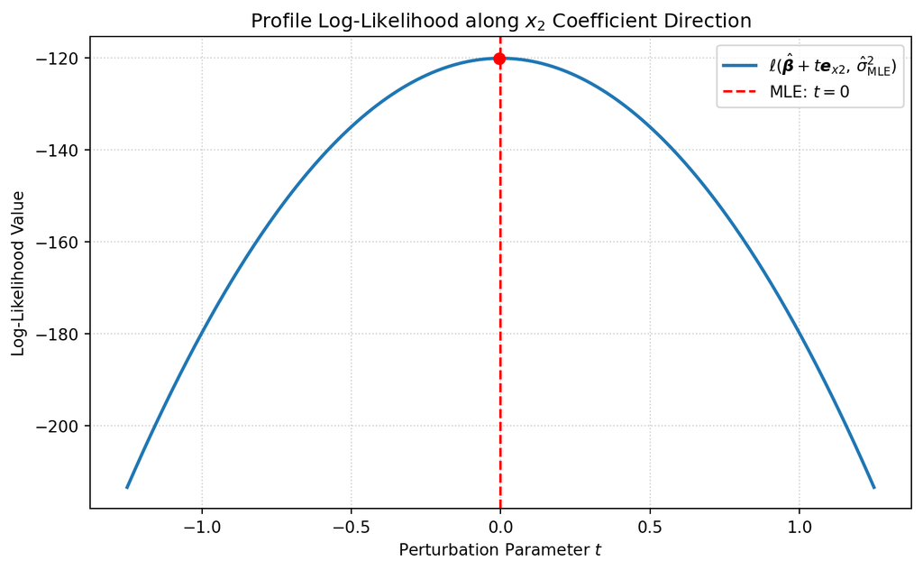

Profile log-likelihood along the x2 coefficient direction.

```
MLE of sigma^2: 0.6466
t value at maximum log-likelihood: -0.0042
```

## Question 3 (Starting values in nonconvex optimization)

### Answer

#### a. Features affecting numerical optimization

The function has several features that affect numerical optimization.

- **Fluctuations in $[-10,4]$:** The curve goes up and down with obvious bends in this region. The starting point $x^{(0)}$ should be selected with this curved region in mind. An adaptive gradient method can take larger steps where the objective is flat and smaller steps where the curve changes rapidly.
- **Sudden slope explosion for $x>4$:** The slope increases rapidly to the right because of the $\\exp(1.5x)$ term. Step sizes must be small enough to prevent the gradient from becoming very large and causing numerical errors.
- **Unbounded growth and the search interval:** The function tends to positive infinity on the far right and also as $x\to-\infty$ because of the $-0.05x^3$ term. Restricting the numerical plot to a bounded interval such as $[-40,7]$ keeps the numerical search from running off to infinity.

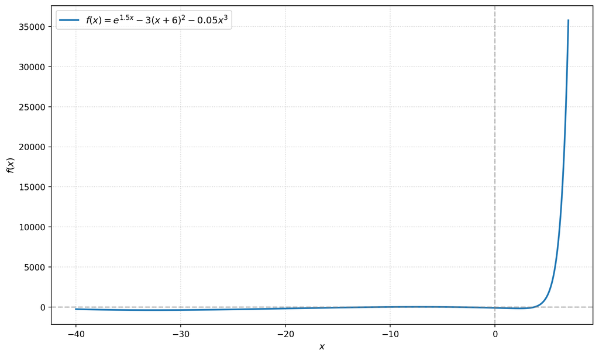

Objective function over the requested plotting interval.

#### b. BFGS optimization results

| Starting value $x^{(0)}$ | Final $x$ | Final $f(x)$ | $\lvert f'(x)\rvert$ | Converged |
| --- | --- | --- | --- | --- |
| -15 | -32.649111 | -390.385770 | $2.842171\times10^{-14}$ | True |
| 0 | 2.349967 | -175.862620 | $8.126811\times10^{-6}$ | True |

Both optimization runs report successful convergence as the gradient norm $\lvert f'(x)\rvert$ approaches zero in both cases. However, starting at $x^{(0)}=-15$ leads to a local minimum at $x\approx-32.65$, whereas starting at $x^{(0)}=0$ converges to a different local minimum at $x\approx2.35$. This behavior is expected because the objective function $f(x)$ is non-convex, making local search algorithms such as BFGS highly dependent on the initial point $x^{(0)}$.

#### c. Dependence on the starting value and the global minimum

The objective function $f(x)$ is non-convex with multiple local minima across $[-40,7]$. BFGS is a local optimization algorithm that relies on local gradient information. Starting at $x^{(0)}=-15$ places the optimizer in the basin of attraction of the local minimum near $x\approx-32.65$, whereas starting at $x^{(0)}=0$ leads it to the local minimum near $x\approx2.35$. Because gradient-based local searches stop as soon as $\lvert f'(x)\rvert\approx0$, neither run can escape its respective local basin.

The first run, with $x^{(0)}=-15$, gives the lower objective value:

- $f(-32.65)\approx-390.39$;
- $f(2.35)\approx-175.86$.

## Question 4 (Nearly collinear predictors)

### Answer

#### a. Fits using $\mathbf X$ and $\mathbf X_+$

For the fit of $\boldsymbol y$ using the original design matrix $\boldsymbol X$, the condition number is $1.5163\times10^0$ and the training RMSE is $0.804118$.

For the fit of $\boldsymbol y$ using the augmented design matrix $\boldsymbol X_+$, the condition number is $2.3378\times10^4$ and the training RMSE is $0.802855$. The coefficient of $\boldsymbol x_1$ is $499.505692$, and the coefficient of $\boldsymbol x_6$ is $-498.136418$.

#### b. Fit of $\boldsymbol y^\star$ using $\mathbf X_+$

For the fit of $\boldsymbol y^\star$ using $\boldsymbol X_+$, the new coefficient of $\boldsymbol x_1$ is $489.505692$ and the new coefficient of $\boldsymbol x_6$ is $-488.136418$. Therefore,

$$\Delta\widehat\beta_1=-10.000000,
\qquad
\Delta\widehat\beta_6=10.000000.$$

The root mean squared difference between the fitted-value vectors is $9.159975\times10^{-4}$, and the maximum absolute difference is $2.867863\times10^{-3}$.

The identity

$$\boldsymbol y^\star-\boldsymbol y
=
10(\boldsymbol x_6-\boldsymbol x_1)$$

shows that the perturbation added to the target vector is $\Delta\boldsymbol y=10^{-3}\boldsymbol u =10(\boldsymbol x_6-\boldsymbol x_1)$.

#### c. Coefficient instability

Because $\boldsymbol x_1$ and $\boldsymbol x_6$ are nearly collinear,

$$\boldsymbol x_6-\boldsymbol x_1=10^{-4}\boldsymbol u,$$

severe multicollinearity acts as a mathematical amplifier. To absorb the small target change of $0.001\boldsymbol u$, the least-squares estimator shifts the two slope coefficients in opposite directions by $\Delta\widehat\beta_1=-10$ and $\Delta\widehat\beta_6=10$.

When predictors are nearly collinear, individual coefficients cannot be interpreted as the separate, independent effect of each predictor. The model cannot disentangle the individual contribution of $\boldsymbol x_1$ from $\boldsymbol x_6$.

## Question 5 (Data preparation and summary statistics)

### Answer

#### a. Data preparation

The original data have dimensions $24\times5$. The column types are `object` for `observation_id` and `group`, and `float64` for `x1`, `x2`, and `response`. There are no duplicated observation identifiers.

The number of missing values in each column is:

| Column | Missing values |
| --- | --- |
| `observation_id` | 0 |
| `group` | 0 |
| `x1` | 0 |
| `x2` | 0 |
| `response` | 3 |

After removing observations with a missing `response`, the analysis table has dimensions $21\times6$. The additional column is defined as $\texttt{feature\_sum}=\texttt{x1}+\texttt{x2}$.

```
Dimensions: (24, 5)

Column types:
observation_id     object
group              object
x1                float64
x2                float64
response          float64
dtype: object

Duplicated observation IDs: 0

Missing values by column:
observation_id    0
group             0
x1                0
x2                0
response          3
dtype: int64

Analysis table dimensions: (21, 6)
```

#### b. Group summaries

| Group | Observations | Mean response | Mean `feature_sum` |
| --- | --- | --- | --- |
| A | 7 | 5.6000 | 3.6000 |
| B | 7 | 7.6029 | 4.9286 |
| C | 7 | 7.9971 | 6.5857 |

These summaries describe only the 21 observations with a recorded, nonmissing `response` value. They exclude `obs-04`, `obs-11`, and `obs-20`, whose response values are missing.

#### c. Largest responses and data checks

The three largest recorded responses are:

| `observation_id` | `group` | `response` | `feature_sum` |
| --- | --- | --- | --- |
| `obs-22` | C | 9.24 | 6.6 |
| `obs-16` | B | 9.00 | 5.2 |
| `obs-14` | B | 8.66 | 5.0 |

The code checks confirm that the number of retained rows equals the number of nonmissing responses in the original data, the analysis table has no missing response values, and its identifiers are unique.

```python
largest_three = (
  analysis_data.sort_values("response", ascending=False)
  .loc[:, ["observation_id", "group", "response", "feature_sum"]]
  .head(3)
)

number_recorded = data["response"].notna().sum()
assert len(analysis_data) == number_recorded
assert not analysis_data["response"].isna().any()
assert analysis_data["observation_id"].is_unique

print("All analysis-table checks passed.")
print(largest_three)
```

```
All analysis-table checks passed.
   observation_id group  response  feature_sum
21         obs-22     C      9.24          6.6
15         obs-16     B      9.00          5.2
13         obs-14     B      8.66          5.0
```

## Question 6 (Can 39 million Fitbit records represent US adults?)

### Answer

#### a. Independent observations and unequal weighting

The daily records are not independent observations because repeated days from the same person are naturally correlated. For example, a person’s activity today can be associated with their activity on the following day because of their health, routine, occupation, or fatigue.

Participants can contribute unequal numbers of recorded days. Active individuals, retirees with more free time, or people who consistently wear and synchronize their Fitbit may contribute records over many years. In contrast, busy workers or lower-income individuals may stop participating sooner, forget to charge the device, or record fewer days.

#### b. Selection bias versus causation

The comparison does not show that already owning a Fitbit causes people to walk more. It can reflect selection bias. People in the BYOD group may have been health-conscious, wealthier, and more active before the study, which could have motivated them to purchase a Fitbit. The WEAR group received devices at no cost and may include people without a prior tracking habit. Therefore, the difference between 6,867 and 5,797 median daily steps can reflect pre-existing lifestyle differences rather than an effect of device ownership.

#### c. Why the naive average fails to estimate the target

Selection of participants can make the observed dataset different from the population of US adults. The data may exclude lower-income, less technology-literate, or marginalized populations who have less access to research programs or wearable devices.

Selection also occurs across days. People contribute records only when they wear and synchronize the device. Days during illness, nonstandard work schedules, or periods without device use may be missing.

The target gives every US adult equal weight. The naive average fails to estimate it because it uses an unrepresentative sample of adults, overweights individuals who wear the device longer, and includes only days on which the device is actively worn.